# R & RStudio Setup Tutorial

2026-04-09

# 1 Welcome

This tutorial walks you through **installing R and RStudio**, **configuring your environment**, and **verifying everything works** with a simple test script. It is written as an **R Markdown (Rmd)** file that you can **Knit to HTML**.

By the end, you will be able to:

- Install **R** (the programming language)
- Install **RStudio** (the editor/IDE)
- Configure basic settings
- Run a test script and create an HTML file

# 2 What Are R and RStudio?

- **R** is a programming language for statistics, data science, and visualization.
- **RStudio** is a user-friendly application that makes working with R much easier.

> ✅ You must install **R first**, then **RStudio**.

# 3 Step 1: Install R

## 3.1 Download R

1. Go to the Comprehensive R Archive Network (CRAN): https://cran.r-project.org/
2. Choose your operating system:
   - **Windows**
   - **macOS**
   - **Linux**

## 3.2 Install R (Quick Tips)

### 3.2.1 Windows

- Click **Download R for Windows** → **base** → **Download R-x.x.x**
- Run the installer and accept the defaults

### 3.2.2 macOS

- Click **Download R for macOS**
- Choose the `.pkg` installer for your macOS version
- Open the package and follow the prompts

### 3.2.3 Linux

- Follow the distribution-specific instructions (Ubuntu, Fedora, etc.)
- Many distributions allow installation via the terminal

✅ After installing, you should have the **R** program on your computer.

# 4 Step 2: Install RStudio

1. Go to: https://posit.co/download/rstudio-desktop/
2. Download **RStudio Desktop (Free)**
3. Choose the version for your operating system
4. Install using default options

✅ Open **RStudio** after installation.

# 5 Step 3: Tour of RStudio

When RStudio opens, you should see four main panes:

1. **Source** – where you write scripts and R Markdown files
2. **Console** – where R runs commands
3. **Environment / History** – objects and command history
4. **Files / Plots / Packages / Help** – outputs and documentation

If you only see one pane, go to:

```
View → Panes → Show All Panes
```

# 6 Step 4: Configure Basic Settings

## 6.1 Global Options

In RStudio, go to:

```
Tools → Global Options
```

Recommended settings for beginners:

### 6.1.1 General

- ✅ Restore .RData into workspace at startup: **Unchecked**
- ✅ Save workspace to .RData on exit: **Never**

### 6.1.2 Appearance

- Choose a theme you like (light or dark)
- Set font size so code is easy to read

Click **Apply** → **OK**.

# 7 Step 5: Create Your First R Script

## 7.1 New Script

1. Go to:

```
File → New File → R Script
```

2. Save it as:

```
setup_test.R
```

## 7.2 Test Code

```r
# Basic R test
x <- c(2, 4, 6, 8)
mean(x)
```

```
## [1] 5
```

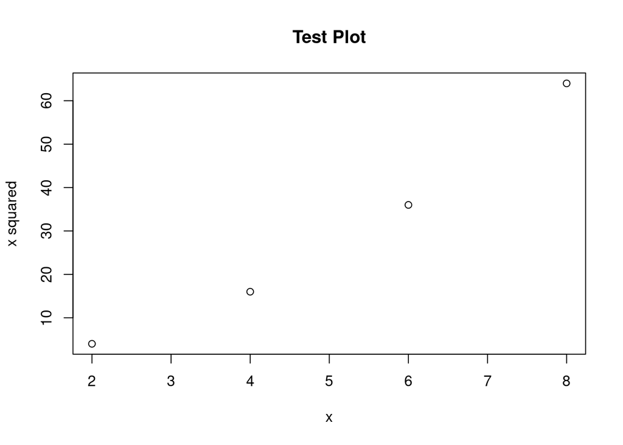

```r
# Simple plot
plot(x, x^2,
     main = "Test Plot",
     xlab = "x",
     ylab = "x squared")
```

✅ You should see output and a plot.

# 8 Step 6: Create an R Markdown File

1. Go to:

```
File → New File → R Markdown...
```

2. Choose:
- **Title:** “My First R Markdown”
- **Author:** Your name
- **Output format:** HTML

# 9 Step 7: Run and Knit

Click **Knit → Knit to HTML**.

✅ An HTML file will be created and opened.

# 10 Congratulations 🎉

You are set up and ready to use R and RStudio.